# Scientific Computing with Matlab

**Scientific Computing with Matlab**

|  | Prof. Seungchul Lee iSystems Design Lab UNIST http://isystems.unist.ac.kr/ |
| --- | --- |

## Problem

Write a m-code to create an output matrix Y which consists of only even numbers (in order) from the given input X.

For example,

- Input X = [1, 2, …,10]
- Output Y = [2, 4,…,10]

```matlab
X = 1:10;
n = length(X);
Y = [];

for i = 1:n
    if mod(X(i),2) == 0     % if X(i) is an even number
       Y = [Y X(i)];
    end
end

X
Y
```

```
X =

     1     2     3     4     5     6     7     8     9    10


Y =

     2     4     6     8    10
```

## Problem

Given an integer $n$, write a m-code to compute the following:

$$S = 1 + \frac{1}{2} + … + \frac{1}{n}$$

```matlab
% first method

n = 10;
m = zeros(1,n);

for i = 1:n
    m(i) = 1/i;
end

S = sum(m)
```

```
S =

    2.9290
```

```matlab
% second method

n = 10;
temp_sum = 0;

for i = 1:n
    temp_sum = temp_sum + 1/i;
end

S = temp_sum
```

```
S =

    2.9290
```

## Problem

Plot $\;f(t) = \frac{3}{2} \sin^2(t) + 3 \cos^2(t) + 1\;$ for $\;0\leq t \leq 3$, and find $\,t\,$ that minimizes $f(t)$.

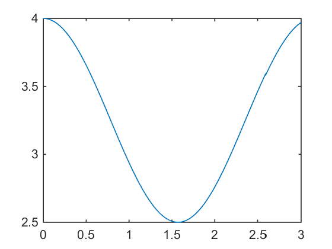

```
ans =

    1.5700
```

```matlab
t = 0:0.01:3;
x1 = sin(t);
x2 = cos(t);

a1 = 1.5;
a2 = 3;
a3 = 1;

f = a1*(x1.^2) + a2*(x2.^2) + a3;

plot(t,f)

[Y, I] = min(f);
t(I)
```

## Problem

Plot $\;f(x) = \sin{x} \cdotp e^x + \log_{10}(3x) + \frac{1}{\sqrt{2x + 7}}\;$ for $\;0 \leq x \leq \pi$, and find $x$ that maximizes $f(x)$.

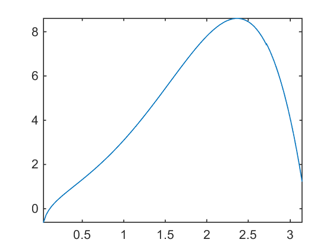

```matlab
x = linspace(0,pi,100);
y = sin(x).*exp(x) + log10(3*x) + 1./sqrt(2*x + 7);

plot(x,y), axis tight
```

## Problem

$M = \begin{bmatrix} 1 & 4 & -3\\ 4 & 2 & 0\\ -3 & 0 & 3 \end{bmatrix}$, calculate $\left(M^TM\right)^{-1}M^2$

```matlab
M = [1 4 -3; 4 2 0; -3 0 3];

M'*M
inv(M'*M)

inv(M'*M)*M^2
```

```
ans =

    26    12   -12
    12    20   -12
   -12   -12    18


ans =

    0.0600   -0.0200    0.0267
   -0.0200    0.0900    0.0467
    0.0267    0.0467    0.1044


ans =

    1.0000    0.0000   -0.0000
   -0.0000    1.0000    0.0000
         0         0    1.0000
```

## Problem

We want to write code for calculating $S_n = 1 + \frac{1}{2} + \frac{1}{2^2} + … + \frac{1}{2^n}$

1) $S_n$ if $n=5$

2) find a maximum value of $n$ such that $S_n \leq 1.999$

3) plot $S_n$ with a function of $n \;(\leq 10)$

```matlab
%1)

n = 5;
temp_sum = 0;

for i = 0:n
    temp_sum = temp_sum + 1/(2^i);
end

Sn = temp_sum
```

```
Sn =

    1.9688
```

```matlab
%2)

temp_sum = 0;
n = 0;

while temp_sum <= 1.999,
    temp_sum = temp_sum + 1/(2^n);
    n = n + 1;
end

n - 1
```

```
ans =

    10
```

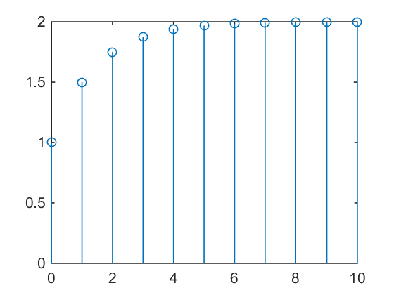

```matlab
%3)

Sn = [];
n = 0:10;
temp_sum = 0;

for i = n
    temp_sum = temp_sum + 1/(2^i);
    Sn = [Sn temp_sum];
end

stem(n,Sn)
```

## Problem

We want to learn about how to numerically take an integral of the given function of $f(x)$.

Calculate $\int^\pi_0 \sin{x}dx$ by using the idea shown in the below figure.

[figure not shown]

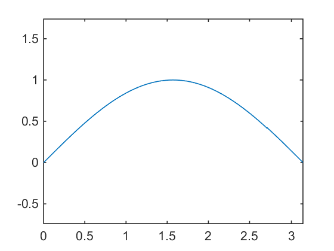

```matlab
a = 0;
b = pi;
delta = 0.01;
x = a:delta:b;
y = sin(x);

plot(x,y), axis equal
```

```matlab
temp_area = 0;
for i = 1:length(x)-1
    temp_area = temp_area + delta*((y(i)+y(i+1))/2);
end
temp_area

temp_area2 = 0;
for i = 1:length(x)-1
    temp_area2 = temp_area2 + delta*y(i);
end
temp_area2
```

```
temp_area =

    2.0000


temp_area2 =

    2.0000
```

## Problem

We want to learn about how to numerically take a derivative of the given function of $f(x)$.

Calculate $\left.\frac{d\sin{x}}{dx}\right|_{x=0}$ by using the idea shown in the below figure.

[figure not shown]

```matlab
a = 0;
delta = 0.01;

dy = (sin(a + delta) - sin(a))/delta
```

```
dy =

    1.0000
```

## Problem

Here, we’d like to numerically find the solutions (roots) of the following equation,

$$f(x) = 4x^3 + 10x^2 - 20x - 10 \quad \text{for} \quad -4 \leq x \leq 3 $$

1) Plot $f(x)$ over $-4 \leq x \leq 3$

2) Numerically find all the roots (solutions) of $f(x) = 0$ with a hint of the below figure.

[figure not shown]

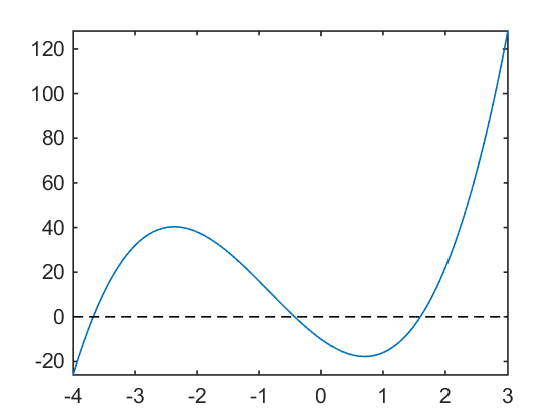

```matlab
% 1)

x = -4:0.01:3;
y = 4*x.^3 + 10*x.^2 - 20*x -10;

plot(x,y,x,zeros(size(x)),'k--'), axis tight
```

```matlab
sol = [];

for i = 1:length(x)-1
    if y(i)*y(i+1) <= 0     % might miss multiple roots
        sol = [sol x(i)];
    end
end

disp(sol)
```

```
-3.6800   -0.4300    1.6000
```

```matlab
% 2)

f2 = [4 10 -20 -10];
x = roots(f2)
```

```
x =

   -3.6753
    1.6004
   -0.4250
```

```matlab
% 3)
syms x
sol = solve('4*x^3 + 10*x^2 - 20*x -10 = 0');
double(sol)
```

```
ans =

    1.6004
   -3.6753
   -0.4250
```

## Problem

Run the following code which explains how to make a kind of animation effect in Matlab.

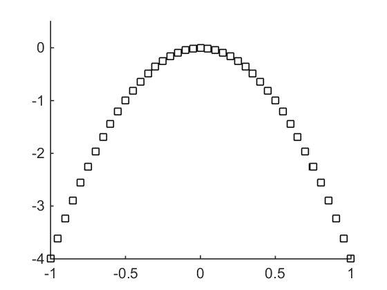

```matlab
% 1)

figure(1); hold on
axis([-1 1 -4 .5])

for x = -1:0.05:1
    y = -4*x^2;
    plot(x,y,'ks')
    pause(0.1)
end
hold off
```

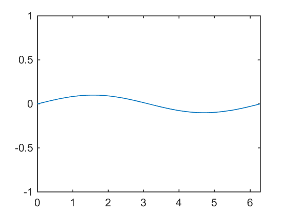

```matlab
%2)

figure(2);  % hold on

x = 0:0.01:2*pi;
for i = 1:10
    y = 1/i*sin(x);
%     cla
    plot(x,y)
    axis([0 2*pi -1 1])
    pause(0.5)
end
% hold off
```

## Problem

Write a code to create a circle as shown in the below figure. (hint: there are many ways to realize this problem, but think about Euler’s formula (http://en.wikipedia.org/wiki/Euler's_formula))

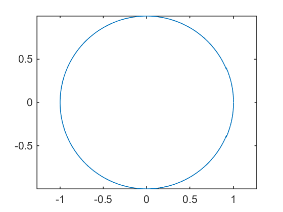

```matlab
theta = 0:0.01:2*pi;

x = cos(theta);
y = sin(theta);

plot(x,y)
axis equal
```

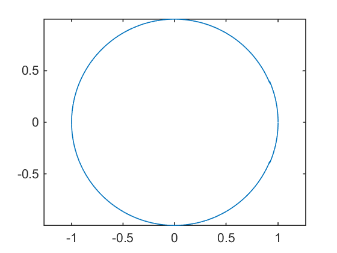

```matlab
theta = 0:0.01:2*pi;
z = cos(theta) + 1i*sin(theta);

plot(real(z),imag(z))
axis equal
```

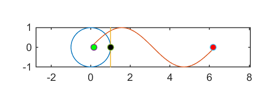

```matlab
%plot -s 560,200

theta = 0:0.01:2*pi;
z = cos(theta) + 1i*sin(theta);

for x = 0:0.1:2*pi
    plot(real(z),imag(z));  hold on
    plot(theta,imag(z))
    plot([1 1],[-1 1])
    axis equal
    w = cos(x) + i*sin(x);
    plot(real(w),imag(w),'o','MarkerFaceColor','g');
    plot(1,imag(w),'o','MarkerFaceColor','k');
    plot(x,imag(w),'o','MarkerFaceColor','r');  hold off
    pause(0.1)
end
```

## Problem

Create an animation which the green dot is moving around the unit circle (counter clockwise).

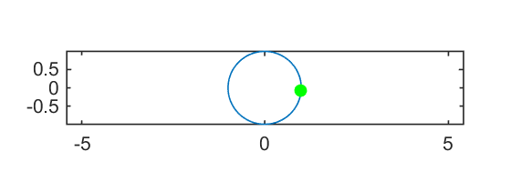

```matlab
%plot -s 560,200

theta = 0:0.01:2*pi;
z = cos(theta) + 1i*sin(theta);

figure(4);  cla;
for x = 0:0.1:2*pi
    plot(real(z),imag(z));  hold on
    axis equal
    w = cos(x) + 1i*sin(x);
    plot(real(w),imag(w),'og','MarkerFaceColor','g');
    hold off
    pause(0.1)
end
```

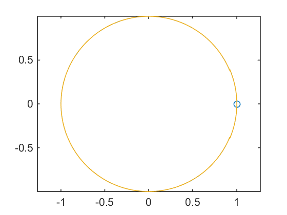

```matlab
%plot -s 560,420

theta = 0:0.01:2*pi;
z = cos(theta) + 1i*sin(theta);

plot(real(z),imag(z));  hold on
axis equal

x = 0:0.001:2*pi;
w = cos(x) + 1i*sin(x);

comet(real(w),imag(w));
hold off
```

## Problem

We want to explore a cycloid (refer to http://en.wikipedia.org/wiki/Cycloid for more information). A cycloid is the curve traced by a point on the rim of a circular wheel as the wheel rolls along a straight line.

[figure not shown]

1) Create a code to plot the cycloid trajectory. Remember there are many ways to do it.

2) Create a code to animate a cycloid by a rolling unit circle.

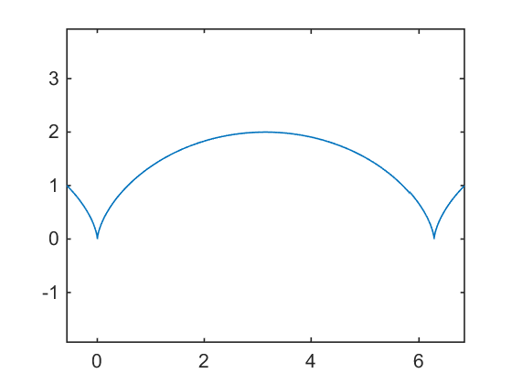

```matlab
%plot -s 560,420

theta = 0-pi/2:0.01:2*pi+pi/2;

x = theta - sin(theta);
y = 1 - cos(theta);

plot(x,y)
axis equal
xlim([min(x),max(x)])
```

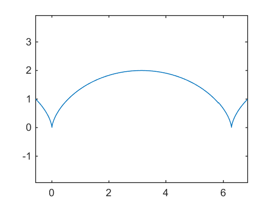

```matlab
%plot -s 560,420

clear z

theta = 0-pi/2:0.01:2*pi+pi/2;
z = theta + 1i - sin(theta) - 1i*cos(theta);

plot(real(z),imag(z))
axis equal
```

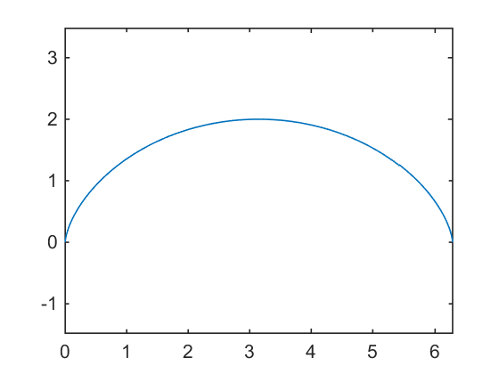

```matlab
clear z

theta = 0:0.01:2*pi;
z = theta + 1i + exp(1i*(3*pi/2-theta));

plot(real(z),imag(z))
axis equal
```

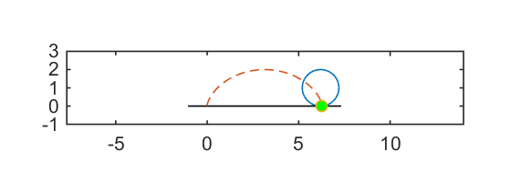

```matlab
%plot -s 560,200

t = 0:0.01:2*pi;
c = 1i + exp(1i*t);

for theta = 0:0.1:2*pi
    w = theta + 1i + exp(1i*(3*pi/2-theta));
    plot(theta + real(c),imag(c));  hold on
    axis([-1 2*pi+1 -1 3])
    axis equal
    plot([-1 2*pi+1],[0 0],'k')
    plot(real(z),imag(z),'--')
    plot(real(w),imag(w),'o','MarkerFaceColor','g');  hold off
    pause(0.05)
%     pause
end
```

## Problem

Let's try more complicated one, hypotrochoid (http://en.wikipedia.org/wiki/Hypotrochoid).

[figure not shown]

1) Write a code to plot the cycloid trajectory with $r = 0.1, 0.2, 0.3, \cdots,0.9$

2) Animate the hypotrochoid with two circles (unit circle and circle with radius r )

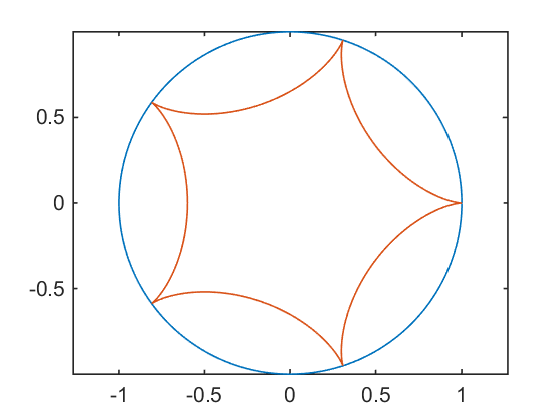

```matlab
%plot -s 560,420

theta = 0:0.01:2*pi;

c = exp(1i*theta);
r = 0.2;
beta = 2*pi + theta*(1-1/r);
z = (1-r)*exp(1i*theta) + r*exp(1i*beta);

plot(real(c),imag(c));  hold on
plot(real(z),imag(z));  hold off
axis equal
```

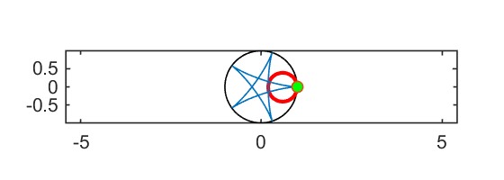

```matlab
%plot -s 560,200

k = 4*pi;

theta = 0:0.01:k;

r = 0.4;
beta = 2*pi + theta*(1-1/r);
c = exp(1i*theta);
z = (1-r)*exp(1i*theta) + r*exp(1i*beta);

for x = 0:0.05:k
    c2 = (1-r)*exp(1i*x) + r*exp(1i*theta);
    w = (1-r)*exp(1i*x) + r*exp(1i*(2*pi + x*(1-1/r)));

    plot(real(c),imag(c),'k');  hold on
    plot(real(c2),imag(c2),'r','linewidth',2);
    plot(real(z),imag(z));
    plot(real(w),imag(w),'o','MarkerFaceColor','g')
    hold off
    axis equal
    pause(0.005)
end
```

## Problem

We want to numerically compute $\pi$ in various ways. Utilize the following equations to write codes. For your reference, the website (http://en.wikipedia.org/wiki/Pi) provides thoughtful backgrounds of how to compute $\pi$.

1) $\int^\infty_{-\infty} \frac{1}{1+x^2} dx = \pi$

2) $\frac{2}{\pi} = \frac{\sqrt{2}}{2} \cdot \frac{\sqrt{2+\sqrt{2}}}{2} \cdot \frac{\sqrt{2+\sqrt{2+\sqrt{2}}}}{2} \cdots$

3) $\pi = \frac{4}{1} - \frac{4}{3} + \frac{4}{5} - \frac{4}{7} + \frac{4}{9} - \frac{4}{11} + \cdots$

```matlab
dx = 0.01;
n = 10000;
x = -n:dx:n;

temp_sum = 0;
for i = 1:length(x)
    temp_sum = temp_sum + dx*(1/(x(i)^2+1));
end

disp(temp_sum)
```

```
3.1414
```

```matlab
r = 0;
temp_prod = 1;

for i = 1:10
    r = sqrt(2+r);
    temp_prod = temp_prod*r/2;
end

disp(2/temp_prod)
```

```
3.1416
```

```matlab
n = 10000;
x = 1:2:n;

temp_sum = 0;
for i = 1:length(x)
    temp_sum = temp_sum -(-1)^i*4/x(i);
end

disp(temp_sum)
```

```
3.1414
```

## Problem

In this problem, we still want to calculate $\pi$ , but it will be a totally different approach, Monte Carlo (MC) methods (probabilistic interpretation). Read the section of the introduction part in the Wikipedia (http://en.wikipedia.org/wiki/Monte_Carlo_method) to understand a fundamental concept of Monte Carlo. Try to understand MC with the given code.

1) Draw a square on the ground, then inscribe a circle within it.

2) Uniformly scatter some objects of uniform size (grains of rice or sand) over the square.

3) Count the number of objects inside the circle and the total number of objects. The ratio of the two counts is an estimate of the ratio of the two areas, which is $\pi$/4.

4) Multiply the result by 4 to estimate $\pi$.

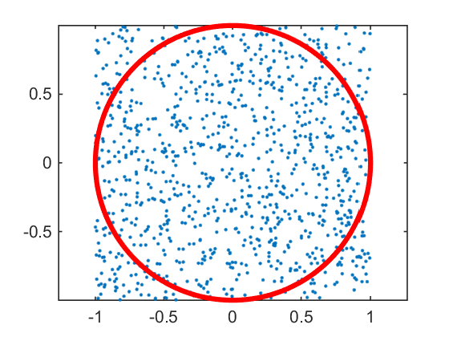

```
3.1720
```

```matlab
%plot -s 560,420

n = 1000;
x = -1 + 2*rand(n,2);       % help rand
count = 0;
for j = 1:n
    if norm(x(j,:)) <= 1    % help norm
        count = count + 1;
    end
end

pi_est = (count/n)*4;
disp(pi_est)

% visualize
w = 0:0.01:2*pi;
z = cos(w) + 1i*sin(w);

figure(1);  cla;    hold on
plot(x(:,1),x(:,2),'.');
plot(real(z),imag(z),'r','linewidth',3);    hold off
axis equal, box on
```